# The Leaven

by Kameron York

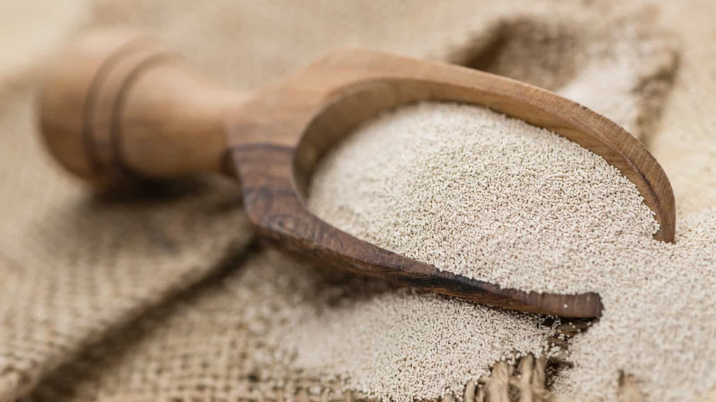

#### Reference:

[Matthew 13:33](https://www.churchofjesuschrist.org/study/scriptures/nt/matt/13?lang=eng&id=33#p33)  
[Luke 13:20-21](https://www.churchofjesuschrist.org/study/scriptures/nt/luke/13?lang=eng&id=20-21#p20)

#### What is Leaven?

Leaven is another name for yeast. Yeast is the ingredient that causes dough to rise. Yeast is actually a living single-celled organism that eats the sugars found in flour and creates a carbon-dioxide gas. Yeast that is old or placed in too hot of water will die and then not cause a rising effect in the bread. Yeast and the miraculous “doubling” it causes in dough are the central figure of this parable.

#### What is the Parable of the Leaven about?

In this parable the Savior tells a story about a woman who adds yeast to a large amount of dough. The yeast causes the, “whole” of the dough to rise. This rising effect is the main focus of the parable. The yeast in the parable is representative of the followers of Jesus Christ. Like the process of yeast causing dough to rise, Christ’s followers are meant to lift the standards of the world around them. Of this Elder M. Russell Ballard said, “We are to lift the world and help all to rise above the wickedness that surrounds us.” To lift others and the world around them is the divine calling of all Christians.

#### What are the Symbols in the Parable of the Leaven?

**The Meal (Dough)** - The World.  
**The Leaven** - Christians. Like yeast, Christians are meant to elevate the world around them.  
**The Woman** - The Lord, placing the Christians where they need to go.